# 95-828 Homework 2

Anurag Gandhi (agandhi1)

February 27, 2017

# 1 Decision Trees

## 1 a. Unbalanced Classes

> When we have unbalanced classes, classification algorithm can lead to misleading results.
> - When classes are unbalanced, we have less training data for the rare class. For example, in the wage predicition example, we only had 3% data points for the “Terminated” class. This does not give enough information to classifier to work on. Classification algorithm tends to favor the dominant class. As such, accuracy on **this** class will be low.
> - To get a better sense of accuracy we can look at F1 scores of under represented class. Accuracy might be high overall, because of the dominant class, but equaly weighing accuracy for each class might give us a better picture.

## 1 b. Balancing the classes

```r
# Import training and test data
term_train <- read.csv('term_train.csv')
term_test <- read.csv('term_test.csv')
set.seed(100)

# Count the number of rows with termination status = 'Terminated'
rows = sum(term_train$STATUS == 'TERMINATED')

# Randomly sample data for active employeees

active_train <- subset(term_train, STATUS == 'ACTIVE')

active_random_sample <- active_train[sample(1:nrow(active_train), rows, replace=FALSE),]

# Combine with data for terminated employees
term_train_balanced <- rbind(subset(term_train, STATUS == 'TERMINATED'), active_random_sample)
```

## 1 c. Fitting the logistic regression model

```r
# FIt the model
logit_term <- glm(STATUS ~ age + length_of_service + STATUS_YEAR + BUSINESS_UNIT + gender_full, data = term_train_balanced,  family = binomial(link = 'logit'))

# Predictions
term_test$predicted_prob <- predict(logit_term, newdata=term_test, type = "response")
term_test$predicted_STATUS <- ifelse(term_test$predicted_prob < 0.5, "ACTIVE", "TERMINATED")

evaluation <- function(term_test, actual, predicted) {
  true_positive <- sum((predicted == 'TERMINATED') & (actual == predicted))
  false_positive <- sum(predicted == "TERMINATED" & actual != predicted)
  true_negative <- sum(predicted == "ACTIVE" & actual == predicted)
  false_negative <- sum(predicted == "ACTIVE" & actual != predicted)

  precision <- true_positive/(true_positive + false_positive)
  recall <- true_positive/(true_positive + false_negative)

  # Confusion matrix
  confusion_matrix <- table(Actual = actual, Predicted = predicted)

  # Misclassification rate
  miscl_rate <- sum(actual != predicted)/nrow(term_test)


  # F1
  f1 <- 2 * ((precision * recall) / (precision + recall))

  return(list(misclassification_rate = miscl_rate, precision = precision, recall = recall, f1 = f1, confusion_matrix = confusion_matrix))

}

eval1 <- evaluation(term_test, term_test$STATUS, term_test$predicted_STATUS)
eval1
```

```
## $misclassification_rate
## [1] 0.1217174
##
## $precision
## [1] 0.1461443
##
## $recall
## [1] 0.6300268
##
## $f1
## [1] 0.2372539
##
## $confusion_matrix
##             Predicted
## Actual       ACTIVE TERMINATED
##   ACTIVE      10668       1373
##   TERMINATED    138        235
```

## 1 d. Information Gain

Attributes sorted by their importance:

```r
library(FSelector)
gains <- information.gain(STATUS ~ age + length_of_service + STATUS_YEAR + BUSINESS_UNIT + gender_full, data = term_train_balanced)
gains
```

```
##                   attr_importance
## age                   0.292501489
## length_of_service     0.178427656
## STATUS_YEAR           0.000000000
## BUSINESS_UNIT         0.003498140
## gender_full           0.004809698
```

```r
# After sorting:
gains$attr_name <- rownames(gains)
gains[order(-1*gains$attr_importance),]
```

```
##                   attr_importance         attr_name
## age                   0.292501489               age
## length_of_service     0.178427656 length_of_service
## gender_full           0.004809698       gender_full
## BUSINESS_UNIT         0.003498140     BUSINESS_UNIT
## STATUS_YEAR           0.000000000       STATUS_YEAR
```

## 1 e. Base decision tree

In this model, we use the features to grow a full decision tree. For the full tree, I set minsplit = 2, minbucket = 1, and cp = -1 in rpart. This gives the tree of maximum complexity. I then use `partykit` library to get the number of terminal nodes.

```r
library("partykit")
library(rattle)
library(rpart)

# Fit full decision tree model
fit <- rpart(STATUS ~ age + length_of_service + STATUS_YEAR + BUSINESS_UNIT + gender_full, data=term_train_balanced, method='class',
             control=rpart.control(cp=-1, minsplit = 2, minbucket = 1))

# Convert to party object
fit_party <- as.party(fit)

# Number of terminal nodes
length(nodeids(fit_party, terminal = TRUE))
```

```
## [1] 410
```

```r
# Depth
nodes <- as.numeric(rownames(fit$frame))
depth <- max(rpart:::tree.depth(nodes))
```

> The number of terminal nodes is 410.

> Depth of tree is 22

> **Potential Problem**: It is evident from the terminal nodes that this is a very complex decision tree model. As such it most likely tends to overfit the training data, and would not generalize to real world data. We should reduce the size of this tree by pruning.

## 1 f. Evaluation for base decision tree:

The evaluation metrics are:

```r
# Predictions on test data
term_test$predicted_STATUS <- predict(fit, term_test, type='class')

# Call the evaluation function
eval2 <- evaluation(term_test, term_test$STATUS, term_test$predicted_STATUS)
eval2
```

```
## $misclassification_rate
## [1] 0.1165619
##
## $precision
## [1] 0.1761158
##
## $recall
## [1] 0.7828418
##
## $f1
## [1] 0.2875431
##
## $confusion_matrix
##             Predicted
## Actual       ACTIVE TERMINATED
##   ACTIVE      10675       1366
##   TERMINATED     81        292
```

## 1 g. Prune by depth

Plot of the resultant tree:

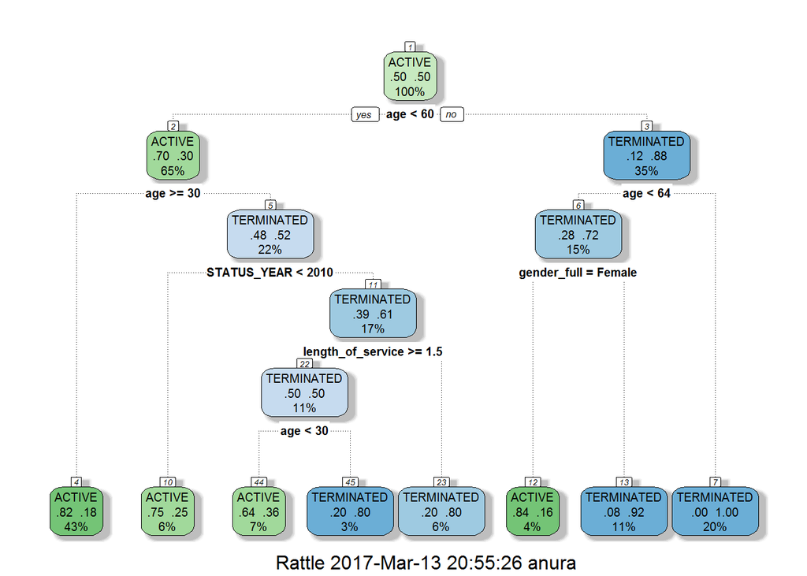

```r
# Set maxdepth = 5
pfit <- rpart(STATUS ~ age + length_of_service + STATUS_YEAR + BUSINESS_UNIT + gender_full, data=term_train_balanced, method='class', control=rpart.control( maxdepth=5))

# predictions
term_test$predicted_STATUS <- NULL
term_test$predicted_STATUS <- predict(pfit, term_test, type='class')

# plot the tree
fancyRpartPlot(pfit)
```

Evaluation metrics:

```r
eval3 <- evaluation(term_test, term_test$STATUS, term_test$predicted_STATUS)
eval3
```

```
## $misclassification_rate
## [1] 0.06436282
##
## $precision
## [1] 0.2865731
##
## $recall
## [1] 0.766756
##
## $f1
## [1] 0.4172137
##
## $confusion_matrix
##             Predicted
## Actual       ACTIVE TERMINATED
##   ACTIVE      11329        712
##   TERMINATED     87        286
```

## 1 h. Cross Validation pruning for size

First, let’s look at the cross validation table from `rpart` object. This gives CV errors for each `cp` parameter and the the size.

```r
# Display the CV cp table
printcp(fit)
```

```
##
## Classification tree:
## rpart(formula = STATUS ~ age + length_of_service + STATUS_YEAR +
##     BUSINESS_UNIT + gender_full, data = term_train_balanced,
##     method = "class", control = rpart.control(cp = -1, minsplit = 2,
##         minbucket = 1))
##
## Variables actually used in tree construction:
## [1] age               BUSINESS_UNIT     gender_full       length_of_service
## [5] STATUS_YEAR
##
## Root node error: 1112/2224 = 0.5
##
## n= 2224
##
##             CP nsplit rel error  xerror     xstd
## 1   0.52877698      0   1.00000 1.03867 0.021189
## 2   0.03552158      1   0.47122 0.47122 0.017998
## 3   0.02652878      3   0.40018 0.42176 0.017300
## 4   0.02023381      5   0.34712 0.35881 0.016272
## 5   0.00989209      7   0.30665 0.31205 0.015390
## 6   0.00719424      8   0.29676 0.30665 0.015280
## 7   0.00539568      9   0.28957 0.31025 0.015353
## 8   0.00269784     12   0.27338 0.29137 0.014962
## 9   0.00179856     14   0.26799 0.30036 0.015151
## 10  0.00134892     15   0.26619 0.30126 0.015169
## 11  0.00089928     25   0.25000 0.30306 0.015206
## 12  0.00071942     43   0.23381 0.30845 0.015317
## 13  0.00065402     56   0.22212 0.30486 0.015243
## 14  0.00059952     67   0.21493 0.31295 0.015408
## 15  0.00051387     79   0.20773 0.31565 0.015461
## 16  0.00044964     86   0.20414 0.32644 0.015673
## 17  0.00038541    116   0.19065 0.32374 0.015621
## 18  0.00035971    123   0.18795 0.32554 0.015656
## 19  0.00029976    128   0.18615 0.34622 0.016045
## 20  0.00026978    165   0.17446 0.34802 0.016078
## 21  0.00025694    185   0.16906 0.34802 0.016078
## 22  0.00022482    192   0.16727 0.35342 0.016176
## 23  0.00019984    204   0.16457 0.35342 0.016176
## 24  0.00017986    220   0.16097 0.35612 0.016224
## 25  0.00000000    233   0.15827 0.35791 0.016256
## 26 -1.00000000    409   0.15827 0.35791 0.016256
```

Now, I select the `cp` value where `xerror` is minimum and prune the tree:

[figure not shown]

```r
# Prune the tree and set cp such that CV error is minimum
pfit<- prune(fit, cp=   fit$cptable[which.min(fit$cptable[,"xerror"]),"CP"])

# Plot the tree
fancyRpartPlot(pfit)
```

```r
# Predictions
term_test$predicted_STATUS <- predict(pfit, term_test, type='class')
```

Evaluation metrics on test data set:

```r
eval4 <- evaluation(term_test, term_test$STATUS, term_test$predicted_STATUS)
eval4
```

```
## $misclassification_rate
## [1] 0.05993233
##
## $precision
## [1] 0.3032874
##
## $recall
## [1] 0.766756
##
## $f1
## [1] 0.4346505
##
## $confusion_matrix
##             Predicted
## Actual       ACTIVE TERMINATED
##   ACTIVE      11384        657
##   TERMINATED     87        286
```

## 1 i. Order of features

> The order of features chosen for the tree is NOT the same as attribute importance rank. The second most important feature according to attribute importance was `length of service`. However, in the tree model, after splitting by age, `STATUS_YEAR` seems to be more important. This is because building the tree is a **recursive** algorithm. The resultant dataset changes after each split, and hence information gain is calculated again at each node. However, while ranking by attribute importance we did not take into account these splits, and so the information gains are different.

## 1 j. Chi square test

In chi-square test, we first convert decision tree into a set of rules. Then we use chi-square test for independence to eliminate variable values which are independent of the label. This simpliies the rule set by eliminating these set of rules.

### What does the chi-square test quantify?

For each split, Chi-square test quantifies the **chance** that we would have seen data of at least this level of association. For the variable X which is being split, the hypothesis is that X is uncorrelated with the decision.

### What is the hyper-parameter and it’s meaning?

The hyperparameter is `maxPchance` : The worst case chance we would be willing to accept. It should be specified at the start of pruning process and can be optimized using **cross validation**.

### Pruning process

- Build the full decision tree
- Choose initial value for `maxPchance`
- When it is impossible to split, start the pruninng process:
- Begin at leaf nodes: For each split calculate `pchance`: which is the probability that we see the association of labels and split **by chance**
- Compare `pchance` against `maxPchance`: if `pchance`>`maxPchance`, delete the split.
- Continue to work upwards until there are no more nodes to prune
- Use cross validation to optimize `maxPchance`

## 1 k. Comparison of models

Looking at the precision, recall, and F1 score: Decision tree pruned by **size** is the best model.

## 1 l. Cost-Benifit Analysis

```r
# Function to calculate expected profit
expected_profit <- function(eval) {

  # P(p)
  prob_p <- sum(term_test$STATUS == 'TERMINATED')/nrow(term_test)

  # P(n)
  prob_n <- 1 - prob_p

  # True positive rate
  tp_rate <- eval$confusion_matrix[2,2]/sum(term_test$STATUS == 'TERMINATED')

  # False negative rate
  fn_rate <- 1 - tp_rate

  # False positive rate
  fp_rate <- eval$confusion_matrix[1,2]/sum(term_test$STATUS == 'ACTIVE')

  # True negative rate
  tn_rate <- 1 - fp_rate

  # Expected profit using cost and benifits from the question
  (prob_p*(tp_rate*2 + fn_rate*(-10)) + prob_n*(tn_rate*0 + fp_rate*(-8)))*1000
}
```

Expected profit (per person in $) using logistic regression model:

```r
expected_profit(eval1)
```

```
## [1] -958.1118
```

Expected profit (per person in $) using base decision tree:

```r
expected_profit(eval2)
```

```
## [1] -898.5017
```

Expected profit (per person in $) using decision tree pruned by depth:

```r
expected_profit(eval3)
```

```
## [1] -482.842
```

Expected profit (per person in $) using decision tree pruned by size:

```r
expected_profit(eval4)
```

```
## [1] -447.3981
```

> Maximum expected profit per person is for the **decision tree model pruned by size**. Based on this analysis, I would chose to deploy this model.

# 2 Support Vector Machines

## 2.2 1. Linear and polynomial SVM

### Linear kernel with C = 0.1

SVM Model fit:

```r
car_mpg <- read.csv('car_mpg.csv')

# Convert output variable to factor
car_mpg <- transform(car_mpg, high_mpg = as.factor(high_mpg))

# Fit a linear SVM model
svm_linear <- svm(high_mpg ~ ., scale = T, cost = 0.1, data = car_mpg, kernel = 'linear')
summary(svm_linear)
```

```
##
## Call:
## svm(formula = high_mpg ~ ., data = car_mpg, cost = 0.1, kernel = "linear",
##     scale = T)
##
##
## Parameters:
##    SVM-Type:  C-classification
##  SVM-Kernel:  linear
##        cost:  0.1
##       gamma:  0.1428571
##
## Number of Support Vectors:  125
##
##  ( 63 62 )
##
##
## Number of Classes:  2
##
## Levels:
##  0 1
```

```r
# Predictions
car_mpg$predicted <- predict(svm_linear, car_mpg)
```

Classification accuracy:

```r
sum(car_mpg$predicted == car_mpg$high_mpg)/nrow(car_mpg)
```

```
## [1] 0.8979592
```

### Polynomial kernel with C = 1 and degree = 3

SVM Model fit:

```r
# Fit a polynomial kernel SVM
svm_polynomial <- svm(high_mpg ~ ., scale = T, cost = 1, data = car_mpg, kernel = 'polynomial', degree = 3)
summary(svm_polynomial)
```

```
##
## Call:
## svm(formula = high_mpg ~ ., data = car_mpg, cost = 1, kernel = "polynomial",
##     degree = 3, scale = T)
##
##
## Parameters:
##    SVM-Type:  C-classification
##  SVM-Kernel:  polynomial
##        cost:  1
##      degree:  3
##       gamma:  0.1111111
##      coef.0:  0
##
## Number of Support Vectors:  139
##
##  ( 69 70 )
##
##
## Number of Classes:  2
##
## Levels:
##  0 1
```

```r
# Predictions
car_mpg$predicted <- predict(svm_polynomial, car_mpg)
```

Classification accuracy:

```r
sum(car_mpg$predicted == car_mpg$high_mpg)/nrow(car_mpg)
```

```
## [1] 0.9183673
```

### Polynomial kernel with C = 1 and degree = 5

SVM Model fit:

```r
# Polynomial kernel SVM
svm_polynomial5 <- svm(high_mpg ~ ., scale = T, cost = 1, data = car_mpg, kernel = 'polynomial', degree = 5)
summary(svm_polynomial5)
```

```
##
## Call:
## svm(formula = high_mpg ~ ., data = car_mpg, cost = 1, kernel = "polynomial",
##     degree = 5, scale = T)
##
##
## Parameters:
##    SVM-Type:  C-classification
##  SVM-Kernel:  polynomial
##        cost:  1
##      degree:  5
##       gamma:  0.1111111
##      coef.0:  0
##
## Number of Support Vectors:  188
##
##  ( 95 93 )
##
##
## Number of Classes:  2
##
## Levels:
##  0 1
```

```r
# Predictions
car_mpg$predicted <- predict(svm_polynomial5, car_mpg)
```

Classification accuracy:

```r
sum(car_mpg$predicted == car_mpg$high_mpg)/nrow(car_mpg)
```

```
## [1] 0.8596939
```

### 2.2 2 (a) CV function

The following function performs cross validation to select the best hyperparameters

```r
#search grid to test function
search_grid <- expand.grid(C = seq(0.01, 1, 0.1), gamma = seq(0.1, 1, 0.1),  KEEP.OUT.ATTRS = FALSE)

# Function for cross validation
CV_SVM <- function(k, grid, data) {

  # Generate fold indices
  fold_indices <- cut(seq(1:nrow(data)),
                       breaks=k,
                       labels = F)

  # Format for output
  output_matrix <- data.frame(fold = c(1:k))
  hp_matrix <- as.data.frame(matrix(0, ncol=nrow(grid), nrow=k, dimnames=list(NULL, c(1:nrow(grid)))))
  output_matrix <- cbind(output_matrix, hp_matrix)

  # Loop for each fold
  for (fold in c(1:k)) {

    # Create training and validation sets
    training <- data[fold_indices != fold,]
    validation <- data[fold_indices == fold,]

    # Fit SVM for each combination
    for (i in 1:nrow(grid)) {
      H_C = grid[i,]$C
      H_gamma = grid[i,]$gamma
      svm_model <- svm(high_mpg ~ ., data=training, kernel = 'radial', cost = H_C, gamma = H_gamma, scale = T)
      validation$predicted <- predict(svm_model, validation)

      # Calculate accuracy
      accuracy <- sum(validation$predicted == validation$high_mpg)/nrow(validation)
      output_matrix[fold, i + 1] <- accuracy

    }
    print(paste("Inner Fold #",fold,"done."))

  }

  # Calculate average accuracy for each combination
  averages <- colMeans(output_matrix[,-1])

  # Save the combination with best average CV accuracy
  best_combination <- grid[as.numeric(names(averages)[which.max(averages)]), ]

  # Fit an SVM model again on whole dataset
  svm_model <- svm(high_mpg ~ ., data=data, kernel = 'radial', cost = best_combination$C, gamma = best_combination$gamma)

  # Return parameters
  list(best_combination = as.list(best_combination), model = svm_model, output_matrix = output_matrix)
}
```

Testing the function on sample grid:

```r
#Testing the function
CV_SVM(5, search_grid, car_mpg)
```

```
## [1] "Inner Fold # 1 done."
## [1] "Inner Fold # 2 done."
## [1] "Inner Fold # 3 done."
## [1] "Inner Fold # 4 done."
## [1] "Inner Fold # 5 done."
```

```
## $best_combination
## $best_combination$C
## [1] 0.91
##
## $best_combination$gamma
## [1] 0.3
##
##
## $model
##
## Call:
## svm(formula = high_mpg ~ ., data = data, kernel = "radial", cost = best_combination$C,
##     gamma = best_combination$gamma)
##
##
```

[output cut: 100 more lines]

### 2.2 2 (b) Performing grid search

```r
# Function for OOS performance
OSS_CV <- function(outer_k, inner_k) {

  # Randomize the data
  car_mpg <- car_mpg[sample(nrow(car_mpg)),]

  # Generate fold indices
  fold_indices <- cut(seq(1:nrow(car_mpg)),
                         breaks = outer_k,
                         labels = F)

  # Create hyperparameter grid
  search_grid <- expand.grid(C = 10^seq(-2, 1.5, 0.5), gamma = 10^seq(-3, 1.5, 0.5),  KEEP.OUT.ATTRS = FALSE)

  # Output format
  output <- data.frame(matrix(nrow = outer_k, ncol = 4, dimnames=list(NULL, c("Fold", "CV_chosen_C", "CV_chosen_gamma", "Accuracy"))))

  # Loop for each fold
  for (fold in 1:outer_k) {
    print(paste0("Outer Fold #", fold, " starting.."))

    # Create training and held out sets
    training <- car_mpg[fold_indices != fold,]
    held_out <- car_mpg[fold_indices == fold,]

    # call the inner SVM function
    inner_model <- CV_SVM(inner_k, search_grid, training)

    # Save the best parameters selected
    C <- inner_model$best_combination$C
    Gamma <- inner_model$best_combination$gamma

    # Predictions and accuracy
    held_out$predicted <- predict(inner_model$model, held_out)
    accuracy <- sum(held_out$predicted == held_out$high_mpg)/nrow(held_out)

    # Store all values
    output[fold, ] <- c(fold, C, Gamma, accuracy)

    # Create and save histogram
    accuracies <- list(accuracy = as.vector(as.matrix(inner_model$output_matrix[,-1])))
    accuracy_histogram <- ggplot(data=as.data.frame(accuracies), aes(accuracies$accuracy)) +
    geom_histogram(binwidth = 0.018, fill="#c0392b", alpha=0.75) +
    labs(title = "Histogram for accuracies", x = "Accuracy", y = "Count")
    ggsave(plot=accuracy_histogram, paste0("histogram",fold, ".png"))

  }

  output
}

output <- OSS_CV(5, 10)
```

```
## [1] "Outer Fold #1 starting.."
## [1] "Inner Fold # 1 done."
## [1] "Inner Fold # 2 done."
## [1] "Inner Fold # 3 done."
## [1] "Inner Fold # 4 done."
## [1] "Inner Fold # 5 done."
## [1] "Inner Fold # 6 done."
## [1] "Inner Fold # 7 done."
## [1] "Inner Fold # 8 done."
## [1] "Inner Fold # 9 done."
## [1] "Inner Fold # 10 done."
```

```
## [1] "Outer Fold #2 starting.."
## [1] "Inner Fold # 1 done."
## [1] "Inner Fold # 2 done."
## [1] "Inner Fold # 3 done."
## [1] "Inner Fold # 4 done."
## [1] "Inner Fold # 5 done."
## [1] "Inner Fold # 6 done."
## [1] "Inner Fold # 7 done."
## [1] "Inner Fold # 8 done."
## [1] "Inner Fold # 9 done."
## [1] "Inner Fold # 10 done."
```

```
## [1] "Outer Fold #3 starting.."
## [1] "Inner Fold # 1 done."
## [1] "Inner Fold # 2 done."
## [1] "Inner Fold # 3 done."
## [1] "Inner Fold # 4 done."
## [1] "Inner Fold # 5 done."
## [1] "Inner Fold # 6 done."
## [1] "Inner Fold # 7 done."
## [1] "Inner Fold # 8 done."
## [1] "Inner Fold # 9 done."
## [1] "Inner Fold # 10 done."
```

```
## [1] "Outer Fold #4 starting.."
## [1] "Inner Fold # 1 done."
## [1] "Inner Fold # 2 done."
## [1] "Inner Fold # 3 done."
## [1] "Inner Fold # 4 done."
## [1] "Inner Fold # 5 done."
## [1] "Inner Fold # 6 done."
## [1] "Inner Fold # 7 done."
## [1] "Inner Fold # 8 done."
## [1] "Inner Fold # 9 done."
## [1] "Inner Fold # 10 done."
```

```
## [1] "Outer Fold #5 starting.."
## [1] "Inner Fold # 1 done."
## [1] "Inner Fold # 2 done."
## [1] "Inner Fold # 3 done."
## [1] "Inner Fold # 4 done."
## [1] "Inner Fold # 5 done."
## [1] "Inner Fold # 6 done."
## [1] "Inner Fold # 7 done."
## [1] "Inner Fold # 8 done."
## [1] "Inner Fold # 9 done."
## [1] "Inner Fold # 10 done."
```

```r
output
```

```
##   Fold CV_chosen_C CV_chosen_gamma  Accuracy
## 1    1   31.622777      0.03162278 0.9367089
## 2    2   10.000000      0.31622777 0.8589744
## 3    3   10.000000      0.31622777 0.9230769
## 4    4   31.622777      0.03162278 0.9102564
## 5    5    3.162278      0.31622777 0.8987342
```

#### Confidence Interval for classification accuracy

```r
CI_lower <- mean(output$Accuracy) - 1.96*sd(output$Accuracy)
CI_upper <- mean(output$Accuracy) + 1.96*sd(output$Accuracy)
```

> Confidence interval for classification accuracy is [0.8474405, 0.9636598].

#### Sample histograms for accuracy

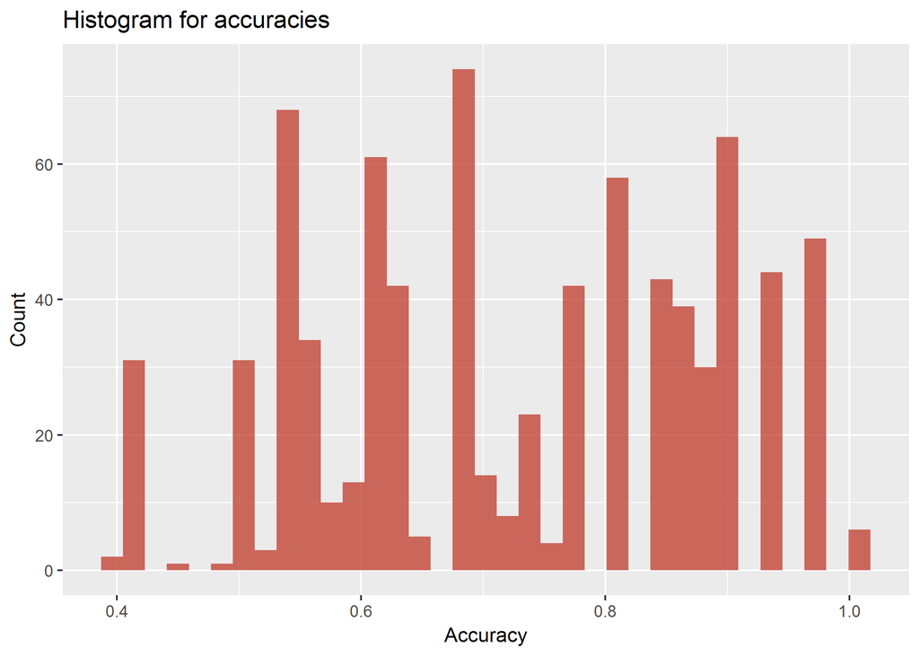

```r
knitr::include_graphics('histogram2.png')
```

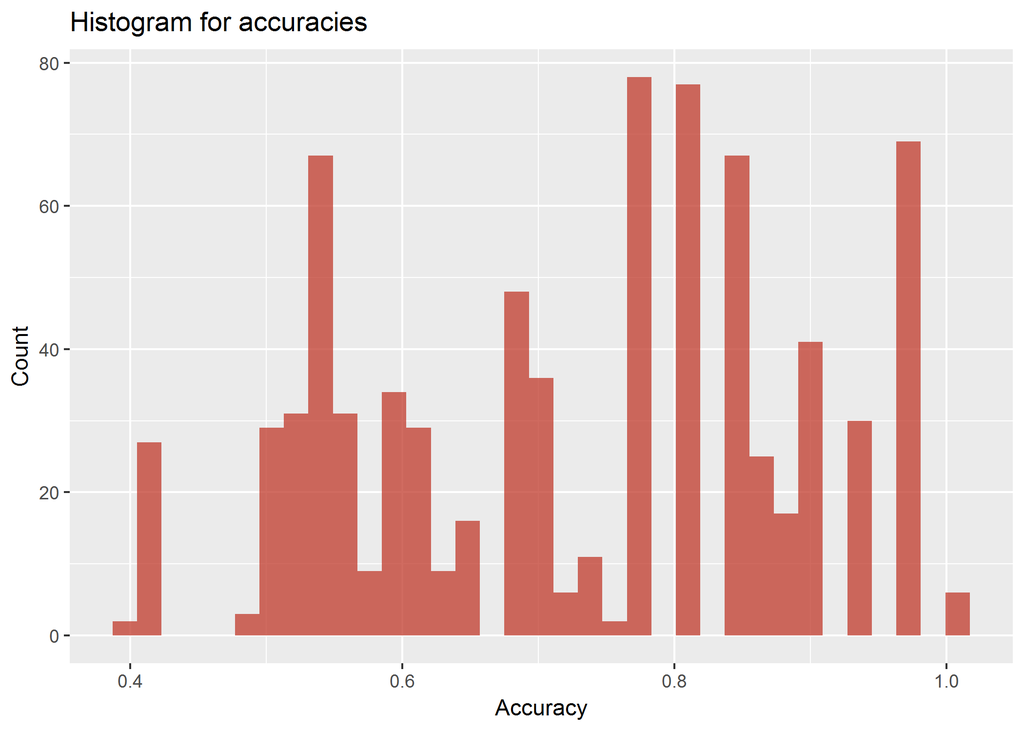

```r
knitr::include_graphics('histogram3.png')
```